# Industry News

Vol. 71

J.H AHN

2022-06-29

## 잡설

꼴랑 1박 출장다녀왔는데 메일은 산더미이고, 몸뚱아리는 피곤에 쩔어 일을 거부하고 있습니다.

아침부터 카페인으로 버티고 있습니다.

장마라 꿀꿀한 날씨지만 잘 버텨내보시죠! ㅎㅎ

### 하나 - PARTI (Pathways Autoregressive Text-to-Image)

구글은 도대체 뭘하려는건지 이런 어마무시한 인공지능을 연일 쏟아내고 있습니다.

이전에 소개한 [Imagen](https://imagen.research.google/)과 유사한 텍스트로 이미지를 만들어 내는 이미지 생성 인공지능입니다.

[Parti](http://parti.research.google/)

친절하게 아래 그림처럼 신경망 모델의 크기에 따라 어떻게 그림이 바뀌는지를 보여주고 있습니다.  
350M, 750M, 3B, 20B 순서인데… 3B(=30억)정도만 되면 실사와 차이를 못느끼겠네요.

[figure not shown]

[figure not shown]

[figure not shown]

[figure not shown]

### 둘 - NASA Picks Three Nuclear Power Concepts for Demonstration on the Moon

[기사링크](https://www.powermag.com/nasa-picks-three-nuclear-power-concepts-for-demonstration-on-the-moon/)

이걸 뉴스에 넣어야 하나 잡설에 넣어야 하나 고민을 잠깐 하다가 잡설에 넣기로 했습니다.

달에 40kW 규모의 원자로를 한 번 지어보겠다는 계획을 나사가 발표했다고 합니다.

록히드 마틴도 포함되어 있고 보잉도 포함되어 있네요.

재미있는게 3가지 제안을 가지고 각각 펀딩하여 진행하는 모양인데 같은 결과물이 나오는데도 경쟁을 할 수 있게 이렇게 다수의 팀에 기회를 준다는 것입니다.

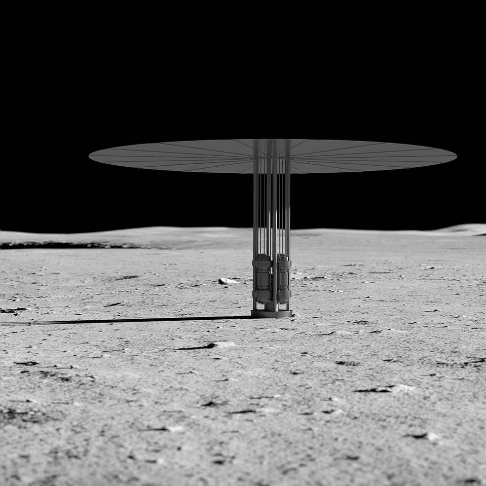

기사내용에는 알 수 없는 각종 신기한 용어들이 등장하는데 이런 것을 볼 때는 미국에서 공돌이의 생활은 재미있을 것 같다는 생각이 들곤 합니다.

## 새로운 소식들

### Tesla Megapacks are about to replace Hawaii’s last remaining coal plant

[기사링크](https://electrek.co/2022/06/27/tesla-megapacks-replace-hawaii-last-remaining-coal-plant/)

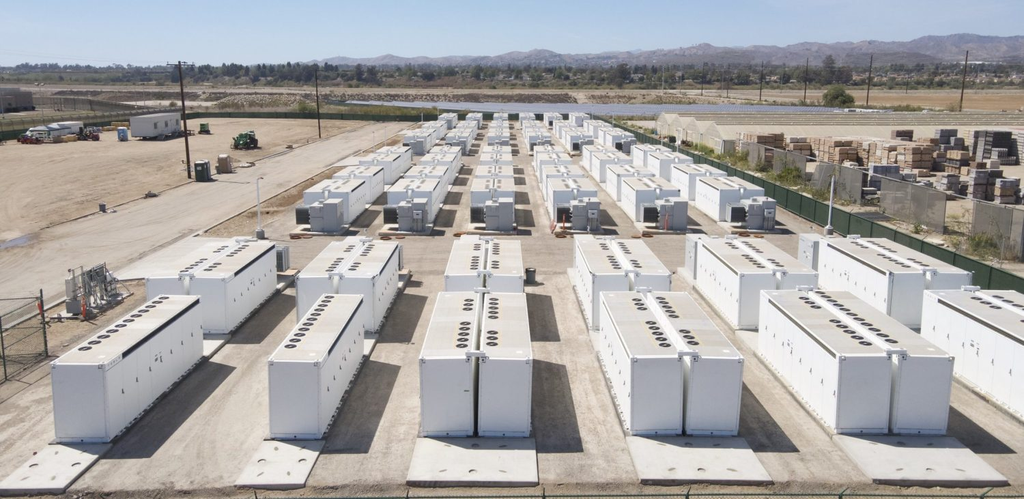

하와이와 같은 섬은 섬들이 모두 각각의 Grid를 구축하고 있어 Carbon Free가 되기 어려운 곳으로 평가받음.

하와이는 2045년까지 100% 탄소중립을 선언하고 향후 태양광+ESS로 발전원을 가져갈 계획을 세우고 금년중 마지막 석탄화력발전소를 폐쇄하고 Tesla의 ESS(185MW/565MWh)를 설치할 계획

어느정도 효용성이 있을지는 지켜봐야 하겠지만 Off-grid 상황에서의 태양광 + ESS 조합의 운영은 우리에게도 큰 시사점을 줄 수 있을 것 같습니다.

### Record clean energy spending is set to help global energy investment grow by 8% in 2022

[기사링크](https://www.iea.org/news/record-clean-energy-spending-is-set-to-help-global-energy-investment-grow-by-8-in-2022)

국제 에너지 기구(International Energy Agency, IEA)에 따르면 2022년 세계 에너지 투자는 전년대비 8% 증가하였고, 이는 대부분 신재생에너지 투자라고 발표.

하지만 이러한 투자는 선진국 및 중국에 편중되어 있고 에너지 안보에 대한 우려와 높은 연료가격으로 인하여 일부 지역에서는 석탄화력에 대한 투자가 증가하기도 하였음.

IEA의 Fatih Birol 사무총장은 “우리는 오늘날의 글로벌 에너지 위기나 기후 위기를 무시할 수 없지만 좋은 소식은 둘 중 하나를 선택할 필요가 없다는 것입니다. 우리는 두 가지 모두를 동시에 해결할 수 있습니다. “청정 에너지 전환을 가속화하기 위한 막대한 투자 급증만이 지속 가능한 유일한 솔루션입니다. 이러한 종류의 투자가 증가하고 있지만 높은 화석 연료 가격으로 인한 소비자의 부담을 완화하고 에너지 시스템을 보다 안전하게 만들고 세계가 기후 목표를 달성하기 위한 궤도에 오르기 위해서는 훨씬 더 빠른 증가가 필요합니다.”라고 평가.

[figure not shown]

### 한수원 사장으로 황주호 경희대 교수 물망

[기사링크](http://www.e2news.com/news/articleView.html?idxno=243303)

인사에 관련된 내용이라 특별히 언급할 부분은 없습니다.

다만 7명 중 콕 집어 이 교수님을 언급한 것은 아마 이유가 있을 것 같습니다.

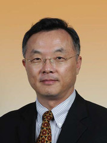

## 전력시장

### Wordcloud for Enerbility

[interactive chart not shown]

### 전력계통

<변동내역>

- 중앙급전발전기 : 변동사항 없음
- 비중앙급전발전기 : 원동풍력#2 신설 등[+25.5MW], 심화제지 태양광 신설 등[+145.2MW]

**best regards,**  
**J.H**

**Industry News?**  
매주 전력산업의 새로운 소식과 산업계 동향을 공유하는 뉴스레터입니다.  
Feedback은 언제라도 환영합니다.  
📫 junho.ahn@doosan.com

**END**